## Question 5

```r
acc_pr <- full_join(acc, per)
head(acc_pr)
```

```
##   STATE ST_CASE VE_TOTAL VE_FORMS PVH_INVL PEDS PERNOTMVIT PERMVIT PERSONS
## 1     1   10001        1        1        0    0          0       1       1
## 2     1   10002        1        1        0    0          0       1       1
## 3     1   10003        3        3        0    0          0       3       3
## 4     1   10003        3        3        0    0          0       3       3
## 5     1   10003        3        3        0    0          0       3       3
## 6     1   10004        1        1        0    0          0       1       1
##   COUNTY CITY DAY MONTH YEAR DAY_WEEK HOUR MINUTE NHS RUR_URB FUNC_SYS RD_OWNER
## 1     73  330  19     2 2017        1   23     35   1       2        1        1
## 2     89 1730  14     2 2017        3   14     59   1       2        1        1
## 3    101 2130  31     1 2017        3   20     31   1       2        1        1
## 4    101 2130  31     1 2017        3   20     31   1       2        1        1
## 5    101 2130  31     1 2017        3   20     31   1       2        1        1
## 6     73  350   1     1 2017        1   16     55   0       2        4        4
##   ROUTE        TWAY_ID       TWAY_ID2 MILEPT LATITUDE  LONGITUD SP_JUR HARM_EV
```

[output cut: 69 more lines]

## Question 6

It seems the day of the week with the most accidents happens on the seventh day (Saturday) with the six day (Friday) being close behind. Next, the hours with the highest amounts of accidents are the 18th hour and the 17th hour. I.e. 5 and 6 o’clock. These hour tend to be when most people begin their way home from work. The least amount of accidents happened during 99 (unknown time). Excluding this we can see the least amount of accidents during a known time is 4 ergo 4am. Most people are asleep at this time. Finally, it shows that men are twice as likely to get into accidents as women are.

```r
day_week <- table(acc_pr$DAY_WEEK)
day_week
```

```
##
##     1     2     3     4     5     6     7
## 13360 10671 10571 10464 11311 13634 14910
```

```r
hour <- table(acc_pr$HOUR)
hour
```

```
##
##    0    1    2    3    4    5    6    7    8    9   10   11   12   13   14   15
## 2928 2540 2735 2096 1706 2269 2880 2824 2183 2301 2719 2952 3716 3888 4223 4839
##   16   17   18   19   20   21   22   23   99
## 4828 5268 5409 4748 4967 4802 4114 3578  408
```

```r
sex <- table(acc_pr$SEX)
sex
```

```
##
##     1     2     8     9
## 55230 28149   473  1069
```

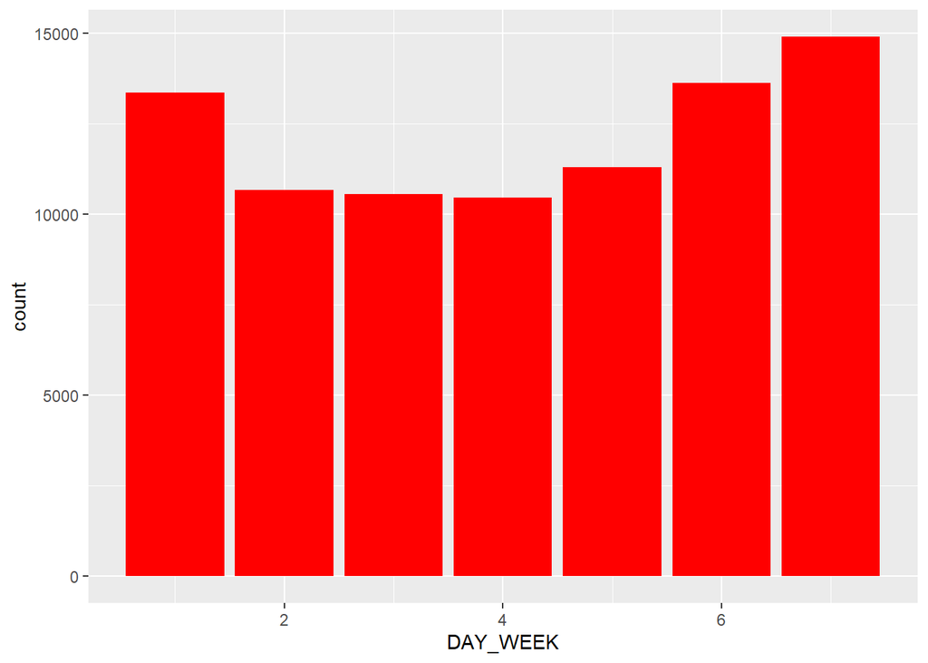

```r
ggplot(acc_pr, aes(DAY_WEEK)) + geom_bar(fill="red")
```

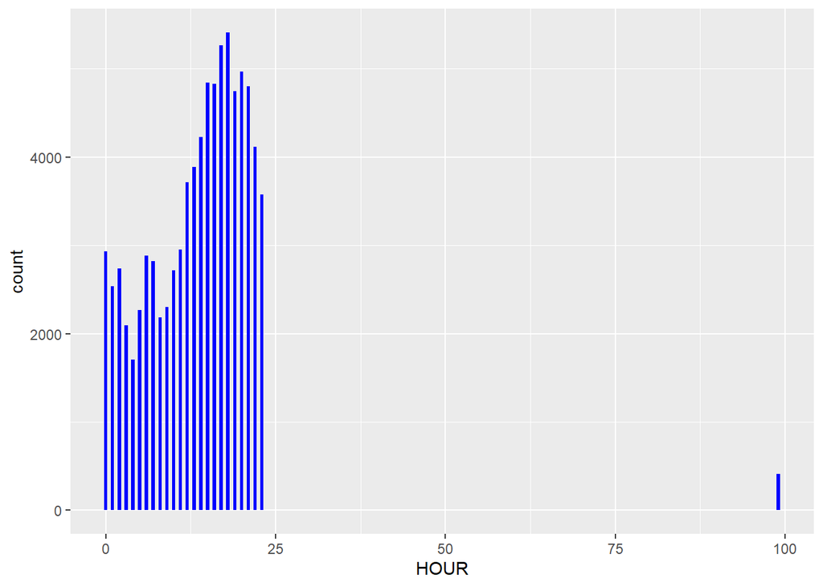

```r
ggplot(acc_pr, aes(HOUR)) + geom_bar(width=0.5, fill="blue")
```

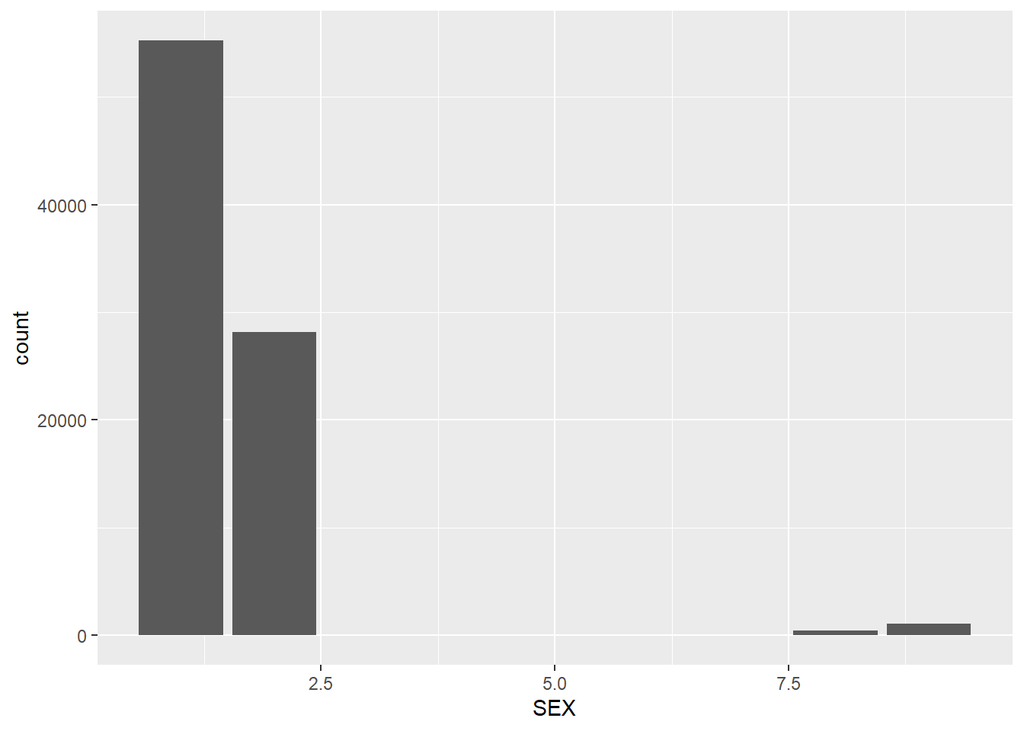

```r
ggplot(acc_pr, aes(SEX)) + geom_bar()
```

## 7

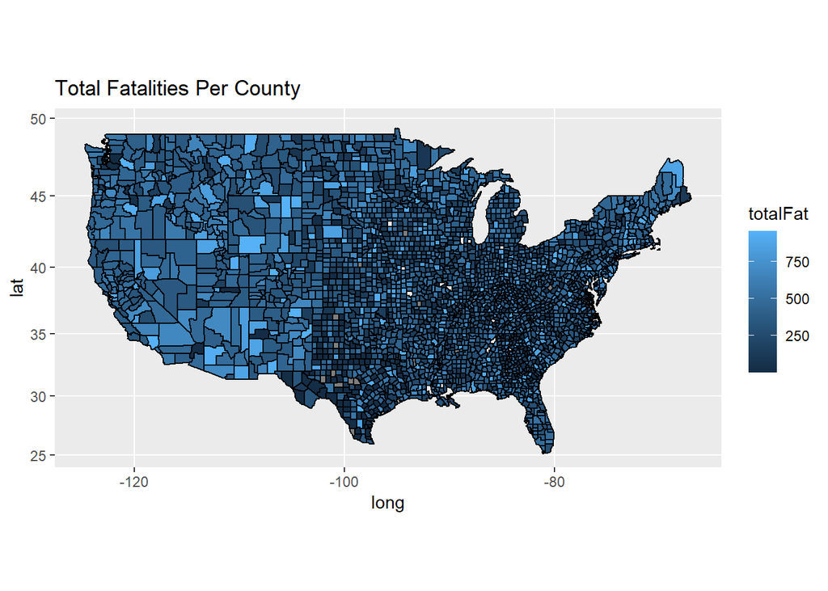

```r
# Variables I'll need: acc- County, Fatals

fatalsByCounty <- acc %>% select('FATALS','COUNTY') %>% group_by(COUNTY) %>%summarize(totalFat = sum(FATALS))

GLC$'County Code' <- as.numeric(GLC$'County Code')
GLC$`County Name` <- tolower(as.character(GLC$`County Name`))

updatedFatalities <- GLC %>% left_join(fatalsByCounty, by=c('County Code'='COUNTY'))

county <-map_data("county")

countycombine<- county %>% right_join(updatedFatalities, by = c('subregion'='County Name')) %>% select('subregion','long','lat','group','order','region', 'totalFat')

countycombine %>% ggplot(aes(x=long,y=lat))+geom_polygon(aes(group = group, fill = totalFat), color = "black")+coord_map()+ggtitle("Total Fatalities Per County")+labs(color="Fatalities")
```

From this graph we can see that areas with a smaller counties tend to have smaller fatality counts. In following with this western look to have a higher total fatalities in general than counties in the middle and east of the country. One explanation for this could be the mountainous regions out west or the fact that highways may have higher fatalities than cities due to a longer response time from emergency vehicles.